# Results

Loong Kuan

16 September 2016

## Original Data of 2 Dates

Load the satellite data set on the day *2013-05-05* and *2013-11-29*.

Data from *2013-05-05*.

```
##      band7    band5    band6 brightness    band3      NDWI    band4     NDVI
## 1 176.8438 317.6875 252.8438   469.4571 90.03125 -113.6550 100.0312 521.0593
## 2  82.8750 340.7500 150.9688   389.4377 50.62500 -385.9549  34.8125 814.6114
## 3  67.0625 362.6250 151.5000   403.7477 47.78125 -410.6492  20.6875 892.0593
## 4  99.1250 348.7500 183.5625   416.6615 63.59375 -310.3205  44.0000 775.9389
## 5 162.1875 308.3750 236.8125   442.9771 82.46875 -131.2622  77.0625 600.1297
##      band1    band2 id_class
## 1 50.56250 59.93750    maize
## 2 30.75000 34.21875    maize
## 3 24.84375 27.15625    maize
## 4 33.59375 36.75000    maize
## 5 50.09375 59.15625    maize
```

Data from *2013-11-29*.

```
##       band7    band5    band6 brightness    band3      NDWI    band4     NDVI
## 1  75.39024 408.2927 144.9024   451.2738 76.17073 -476.1254 50.58537 779.5259
## 2 116.60976 290.8049 184.9024   383.8199 75.34146 -222.6210 79.26829 571.6074
## 3 140.29268 258.4390 206.6585   384.4472 77.46342 -111.3325 92.90243 471.1559
## 4 114.92683 354.6585 178.7805   428.3625 72.21951 -329.7060 66.68293 683.4732
## 5  76.78049 458.0976 145.0488   494.1166 63.78049 -519.0262 38.19512 846.0782
##      band1    band2 id_class
## 1 27.19512 34.12195    maize
## 2 33.51220 43.36585    maize
## 3 38.63415 49.95122    maize
## 4 33.51220 41.90244    maize
## 5 27.19512 33.12195    maize
```

Histogram of the data by attributes.

```
## [1] "Plots Obtained"
```

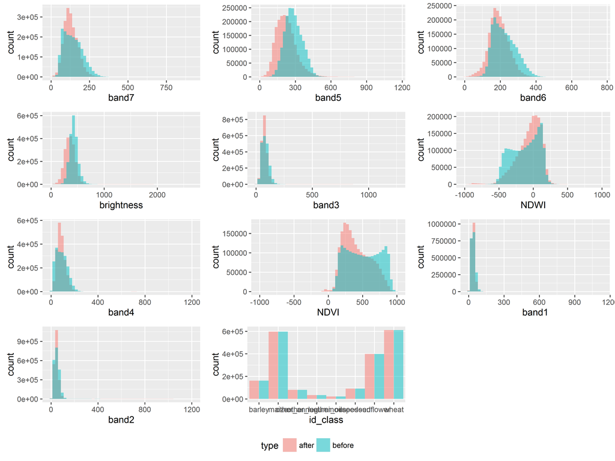

## Drift Results

The raw data of the results will be provided at the end of this document.

### Covariate Drift

The following is the results for a test of 1 Attribute. We can verify the correctness of the results by comparing them to the histograms of the attributes above.

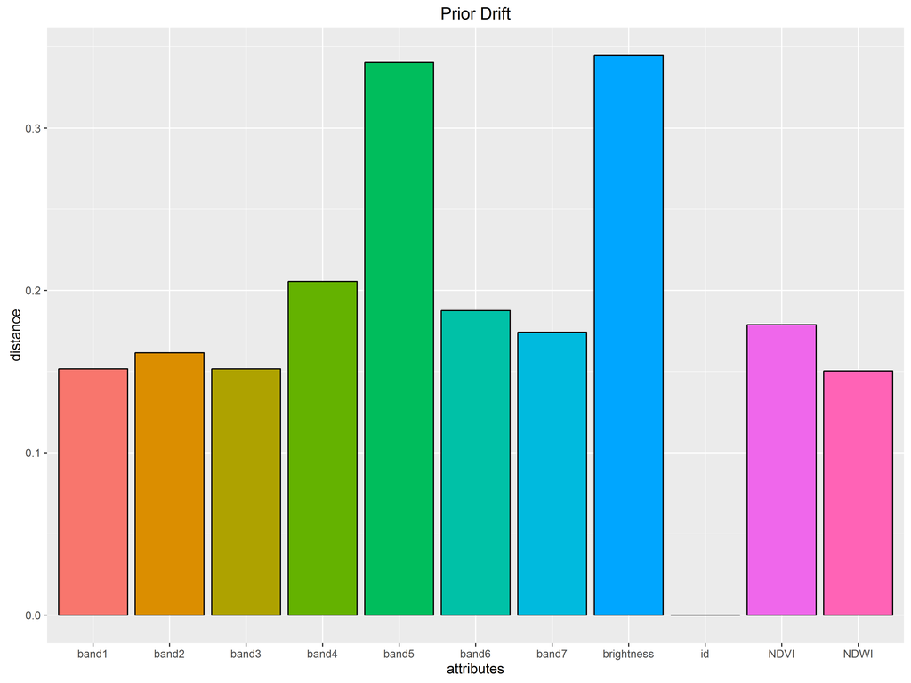

The following is the covariate results for 2 Attributes. This plot is just an exercise on how results from larger amounts of attributes might be visualised.

The plot is made by first constructing a “distance matrix” where the distance obtained for each pair of attribute is represneted.

```
##            [,1]      [,2]      [,3]      [,4]      [,5]      [,6]      [,7]
##  [1,] 0.0000000 0.1852039 0.5935651 0.3310977 0.1971765 0.4653447 0.4653257
##  [2,] 0.1852039 0.0000000 0.2958347 0.6744365 0.2076826 0.2279790 0.4402099
##  [3,] 0.5935651 0.5916695 0.0000000 0.1865022 0.3286062 0.6330485 0.5823350
##  [4,] 0.3310977 0.6744365 0.1865022 0.0000000 0.3750947 0.3586372 0.6708471
##  [5,] 0.1971765 0.2076826 0.3286062 0.3750947 0.0000000 0.2114849 0.2800072
##  [6,] 0.4653447 0.4559581 0.6330485 0.7172743 0.2114849 0.0000000 0.2387909
##  [7,] 0.2326628 0.4402099 0.5823350 0.3354236 0.2800072 0.4775818 0.0000000
##  [8,] 0.5063311 0.5223544 0.7432044 0.7760401 0.2355323 0.5964386 0.6521692
##  [9,] 0.5139728 0.3014186 0.2839069 0.5450264 0.6202702 0.3096456 0.3250424
## [10,] 0.3687543 0.7476673 0.7514836 0.3885567 0.3754833 0.7638281 0.3879593
## [11,] 0.7277142 0.3677211 0.3865281 0.3736012 0.7572136 0.7509775 0.7436572
##            [,8]      [,9]     [,10]     [,11]
##  [1,] 0.5063311 0.2569864 0.3687543 0.7277142
##  [2,] 0.2611772 0.6028373 0.3738336 0.3677211
##  [3,] 0.3716022 0.2839069 0.3757418 0.3865281
##  [4,] 0.7760401 0.5450264 0.7771134 0.7472024
##  [5,] 0.2355323 0.3101351 0.3754833 0.7572136
##  [6,] 0.2982193 0.3096456 0.3819140 0.7509775
##  [7,] 0.6521692 0.6500848 0.7759186 0.7436572
##  [8,] 0.0000000 0.3240444 0.7429283 0.3898107
##  [9,] 0.6480888 0.0000000 0.6915030 0.3968816
## [10,] 0.7429283 0.3457515 0.0000000 0.3832795
## [11,] 0.7796215 0.7937632 0.7665591 0.0000000
```

This matrix is then plotted using Multidimensional Scaling to visualise the distances in the matrix. The final plot will then plot attributes that have a higher dirft together further apart.

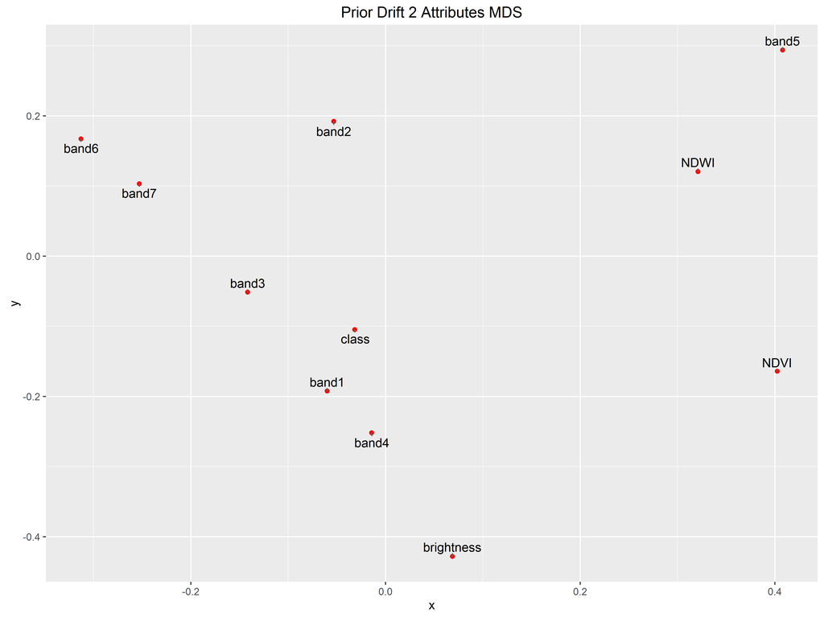

We can also plot the distance matrix as a heatmap to directly view the results. However this method only works with 2 attribute tests.

[interactive chart not shown]

Here is a heatmap for 3 attributes that contains the attribute with the highest variance in difference.

[interactive chart not shown]

### Conditioned Covaraites (Single Attributes)

[interactive chart not shown]

### Conditioned Covaraites (Pair Attributes)

```
## [1] "Plots obtained"
```

[interactive chart not shown]

### Posterior (1 Attribute)

[interactive chart not shown]

## Raw Data

https://github.com/LeeLoongKuan/DriftMapper/tree/master/data_out/martvard

## Raw Plots

https://github.com/LeeLoongKuan/DriftMapper/tree/master/DataAnalysisR/Plots